# Regression Analysis

4. Multiple Linear Regression | Special Lecture for KINS

Boncho Ku, Ph.D. in Statistics

secondmoon@kiom.re.kr

Digital Health Research Division

Korea Institute of Oriental Medicine

2026-09-01

# Multiple Linear Regression

## 설명변수가 여럿일 때

### 질문

**앞 장에서 여기까지**: 온도 하나로 $R^2=0.602$. **이 장의 질문**: 설명변수를 여럿으로 늘리면 계수를 어떻게 읽고, 얼마나 믿을 수 있는가

단순선형회귀의 적합 결과는 $R^2=0.602$ 였다. 소비량 변동의 약 40%는 온도 하나로 설명되지 않은 채 남아 있다.

Ice cream data: n = 30 four-week periods, 6 variables

| Variable | Meaning | Role in this chapter |
| --- | --- | --- |
| `IC` | Per-capita ice cream consumption (pints) | Response $y_i$ |
| `price` | Price of ice cream | Predictor $x_{i1}$ |
| `income` | Income | Predictor $x_{i2}$ |
| `temp` | Mean temperature (°F) | Predictor $x_{i3}$ |
| `period` | Index of the four-week period | Identifier |
| `year` | Observation year code (0/1/2) | Used in the Dummy Variable chapter |

## 아이스크림 자료: 데이터 구조

### 앞 5행

First five rows of the ice cream data (n = 30)

| period | IC | price | income | temp | year |
| --- | --- | --- | --- | --- | --- |
| 1 | 0.386 | 0.270 | 78 | 41 | 0 |
| 2 | 0.374 | 0.282 | 79 | 56 | 0 |
| 3 | 0.393 | 0.277 | 81 | 63 | 0 |
| 4 | 0.425 | 0.280 | 80 | 68 | 0 |
| 5 | 0.406 | 0.272 | 76 | 69 | 0 |

**표의 한 행이 모형의 한 식**

- 한 행 = 4주짜리 관측 기간 하나 = 회귀식 한 줄. 그런 행이 모두 30개
- `IC` 열이 통째로 반응변수 벡터, `price`·`income`·`temp` 열이 설명변수 $x_{i1},x_{i2},x_{i3}$
- 이 표를 숫자 격자로 그대로 옮긴 것이 뒤에 나올 설계행렬

## 설명변수 간 관계 파악: 산점도 행렬

### 사전 자료 탐색

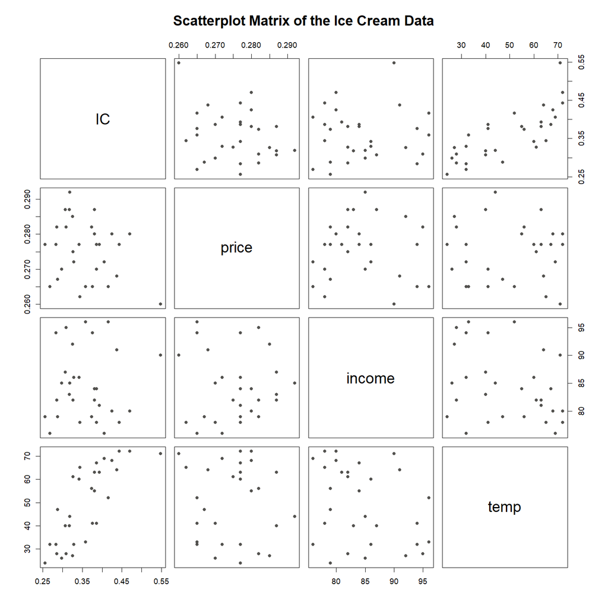

Scatterplot matrix of the ice cream data

**읽는 순서**

- 변수 4개의 모든 짝을 산점도로 그려 한 화면에 배치한 그림
- `temp`와 `IC`가 만나는 칸: 뚜렷한 우상향
- `price`, `income`과 `IC`가 만나는 칸: 방향이 흐릿함
- 설명변수끼리 만나는 칸도 함께 볼 것. 정보가 겹치는지 확인하기 위함

## 다중선형회귀모형: 정의

### 설명변수의 확장

관측 $i=1,\dots,n$ 에 대하여
$$y_i=\beta_0+\beta_1 x_{i1}+\beta_2 x_{i2}+\cdots+\beta_p x_{ip}+\varepsilon_i$$

**기호**

- $y_i$: $i$번째 반응변수(소비량), $x_{ij}$: $i$번째 관측의 $j$번째 설명변수 값
- $\beta_0$: 절편, $\beta_1,\dots,\beta_p$: 각 설명변수의 회귀계수
- $\varepsilon_i$: 평균 0, 분산 $\sigma^2$ 인 오차
- $n$: 관측 수(30), $p$: 설명변수 개수(3)

**조건부 기댓값으로 다시 쓰면**

$$E(Y\mid x_1,\dots,x_p)=\beta_0+\beta_1 x_1+\cdots+\beta_p x_p$$

회귀가 설명변수 조건 아래 반응변수의 평균이라는 정의는 그대로이고, 조건 자리에 놓이는 변수의 개수만 늘어남

Source: Kutner, Nachtsheim, Neter, Li (2005), *Applied Linear Statistical Models*, 5th ed.

## 다중선형회귀모형: 행렬 표현

### 관측 30개의 한 식 표현

$$\mathbf y=\mathbf X\boldsymbol\beta+\boldsymbol\varepsilon$$

$$\mathbf X=\begin{pmatrix}
1 & x_{11} & x_{12} & x_{13}\\
1 & x_{21} & x_{22} & x_{23}\\
\vdots & \vdots & \vdots & \vdots\\
1 & x_{n1} & x_{n2} & x_{n3}
\end{pmatrix}$$

**기호**

- $\mathbf y$: 반응변수 $n$ 개를 쌓은 벡터, $\boldsymbol\varepsilon$: 오차 벡터
- $\mathbf X$: 절편용 1의 열과 설명변수 열을 묶은 $n\times(p+1)$ 설계행렬
- $\boldsymbol\beta$: 회귀계수 벡터($p+1$ 개). 이 자료에서 $\mathbf X$ 는 $30\times 4$

**행렬 곱과 개별 식의 동치**

- 행렬 곱 규칙 = 행과 열을 짝지어 곱한 뒤 더하기
- $\mathbf X\boldsymbol\beta$ 의 $i$ 번째 성분이 $\beta_0+\beta_1x_{i1}+\beta_2x_{i2}+\beta_3x_{i3}$
- 따라서 이 한 줄을 풀어 쓰면 관측별 식 30줄과 정확히 일치

## 아이스크림 자료: 설계행렬

### 표에서 행렬로

**Design matrix for the ice cream data**, $n=30$, $p=3$

$$\underbrace{\begin{pmatrix} y_1\\ y_2\\ \vdots\\ y_{30} \end{pmatrix}}_{\mathbf{y}\;(30\times 1)}
=
\underbrace{\begin{pmatrix}
1 & x_{11} & x_{12} & x_{13}\\
1 & x_{21} & x_{22} & x_{23}\\
\vdots & \vdots & \vdots & \vdots\\
1 & x_{30,1} & x_{30,2} & x_{30,3}
\end{pmatrix}}_{\mathbf{X}\;(30\times 4)}
\underbrace{\begin{pmatrix} \beta_0\\ \beta_1\\ \beta_2\\ \beta_3 \end{pmatrix}}_{\boldsymbol{\beta}\;(4\times 1)}
+
\underbrace{\begin{pmatrix} \varepsilon_1\\ \varepsilon_2\\ \vdots\\ \varepsilon_{30} \end{pmatrix}}_{\boldsymbol{\varepsilon}\;(30\times 1)}$$

- $\mathbf{y}$: 30개 기간의 소비량 `IC` 를 모은 벡터
- $\mathbf{X}$ 의 2, 3, 4열: `price` $x_{i1}$, `income` $x_{i2}$, `temp` $x_{i3}$
- 앞에서 본 표 첫 행의 실제 값: $y_1=0.386$, $x_{11}=0.270$, $x_{12}=78$, $x_{13}=41$

## 최소제곱 해와 정규방정식

### 벡터 미분

1. **목적함수를 전개한다.** 잔차제곱합은 스칼라이므로 전치를 취해도 같은 값. 가운데 두 항이 서로 전치 관계라 하나로 묶임
   $$S(\boldsymbol\beta)=(\mathbf y-\mathbf X\boldsymbol\beta)^\top(\mathbf y-\mathbf X\boldsymbol\beta)
   =\mathbf y^\top\mathbf y-2\boldsymbol\beta^\top\mathbf X^\top\mathbf y+\boldsymbol\beta^\top\mathbf X^\top\mathbf X\boldsymbol\beta$$
2. **2장의 미분 공식 둘을 그대로 쓴다.** $\dfrac{\partial(\boldsymbol\beta^\top\mathbf a)}{\partial\boldsymbol\beta}=\mathbf a$ 와 $\dfrac{\partial(\boldsymbol\beta^\top\mathbf A\boldsymbol\beta)}{\partial\boldsymbol\beta}=2\mathbf A\boldsymbol\beta$ ($\mathbf A$ 가 대칭일 때). 첫 항은 $\boldsymbol\beta$ 가 없으므로 사라짐
   $$\frac{\partial S}{\partial\boldsymbol\beta}=-2\mathbf X^\top\mathbf y+2\mathbf X^\top\mathbf X\boldsymbol\beta$$
3. **$\mathbf 0$ 으로 놓으면 정규방정식.** $\mathbf X$ 가 full rank이면 $(\mathbf X^\top\mathbf X)^{-1}$ 가 존재하므로 양변 왼쪽에 곱해 해를 얻음
   $$\mathbf X^\top\mathbf X\boldsymbol\beta=\mathbf X^\top\mathbf y$$

$$\therefore\hat{\boldsymbol\beta}=(\mathbf X^\top\mathbf X)^{-1}\mathbf X^\top\mathbf y$$

## 최소제곱 해가 존재할 조건

### $\mathbf X$ 의 full rank 조건

$\mathbf X$ 가 $n\times(p+1)$ 이고 $\operatorname{rank}(\mathbf X)=p+1\;(\le n)$ 일 때, 그리고 그때만 $(\mathbf X^\top\mathbf X)^{-1}$ 가 존재하고 최소제곱 해가 유일하게 정해진다.

- 2장에서 본 사슬 그대로. $\operatorname{rank}(\mathbf X^\top\mathbf X)=\operatorname{rank}(\mathbf X)$ 이므로, $\mathbf X$ 가 full rank가 아니면 $\det(\mathbf X^\top\mathbf X)=0$ 이고 역행렬이 없음
- 깨지는 경우 둘. 어떤 설명변수가 다른 설명변수들의 **정확한 선형결합**일 때(예: 섭씨와 화씨를 함께 투입), 그리고 **$n<p+1$** 로 관측이 계수보다 적을 때

**아이스크림 완전모형**: $n=30$, $p=3$ 이므로 $\mathbf X$ 는 $30\times 4$. $\operatorname{rank}(\mathbf X)=4=p+1$ 로 full rank이며 해가 유일하게 정해짐

잔차제곱합은 두 가지로 같게 계산됨: $\mathbf e^\top\mathbf e=\mathbf y^\top\mathbf y-\hat{\boldsymbol\beta}^\top\mathbf X^\top\mathbf y=0.035313$

## 모자행렬: 정의

### 적합값을 만드는 행렬

$$\mathbf H=\mathbf X(\mathbf X^\top\mathbf X)^{-1}\mathbf X^\top,\qquad \hat{\mathbf y}=\mathbf X\hat{\boldsymbol\beta}=\mathbf H\mathbf y$$

**기호**

- $\mathbf H$: 설계행렬 $\mathbf X$ 만으로 결정되는 $n\times n$ 행렬, $\hat{\mathbf y}$: 적합값 벡터
- $\mathbf y$ 에 곱해 주면 $\mathbf y$ 가 모자를 쓴 $\hat{\mathbf y}$ 가 된다고 해서 **모자행렬(hat matrix)**

**잔차도 같은 방식으로 얻는다**

$$\mathbf e=\mathbf y-\hat{\mathbf y}=(\mathbf I-\mathbf H)\mathbf y$$

$\mathbf I$: $n\times n$ 항등행렬, $\mathbf e$: 잔차 벡터($e_i=y_i-\hat y_i$). 적합값과 잔차가 모두 $\mathbf y$ 의 선형변환으로 표현됨

Source: Hoaglin, D. C., & Welsch, R. E. (1978). The hat matrix in regression and ANOVA. *The American Statistician*, 32(1), 17-22.

## 모자행렬: 직교사영

### 최소제곱의 기하학적 의미

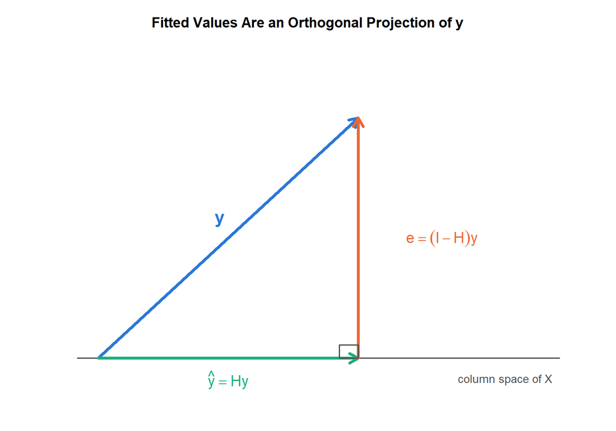

Fitted values as an orthogonal projection of y onto the column space of X

**그림이 말하는 것**

- $\hat{\mathbf y}=\mathbf H\mathbf y$ 는 $\mathbf y$ 를 $\mathbf X$ 의 열공간(column space)에 수직으로 내린 사영
- 잔차 $\mathbf e=(\mathbf I-\mathbf H)\mathbf y$ 는 그 열공간에 직교: $\mathbf X^\top\mathbf e=\mathbf 0$
- 직교하므로 $\hat{\mathbf y}$ 는 열공간 위의 점 가운데 $\mathbf y$ 에 가장 가까운 점

## 모자행렬: 성질과 확인

### 대칭, 멱등, 대각합

**성질**

Properties of the hat matrix verified on the full model (n = 30, p = 3)

| Property | Expression | Ice cream full model |
| --- | --- | --- |
| Size | $n\times n$ | $30\times 30$ |
| Symmetry | $\mathbf H^\top=\mathbf H$ | 성립 |
| Idempotence | $\mathbf H\mathbf H=\mathbf H$ | 성립 |
| Trace | $\operatorname{tr}(\mathbf H)=p+1$ | 4 |
| Mean leverage | $(p+1)/n$ | 0.133 |

멱등은 이미 사영한 것을 다시 사영해도 그대로라는 뜻. 대각합 $\operatorname{tr}(\mathbf H)$ 는 대각원소의 합이며 추정한 계수의 개수 $p+1=4$ 와 일치

**다음 장 예고**

- 대각원소 $h_{ii}$ = **레버리지(leverage)**, 곧 $i$번째 관측이 자기 적합값을 끌어당기는 힘의 크기
- 이 자료의 평균 레버리지 $4/30=0.133$, 최댓값 0.278(관측 9)
- 레버리지가 큰 관측이 결과를 좌우하는지 판정하는 기준은 다음 장에서

## 모자행렬: 세 성질의 증명

### 대칭성에서 나오는 셋

$\mathbf X^\top\mathbf X$ 가 대칭이므로 그 역행렬도 대칭. 이 사실만으로 세 성질이 모두 나옴

$$\begin{aligned}
\mathbf H^\top &=\big\{\mathbf X(\mathbf X^\top\mathbf X)^{-1}\mathbf X^\top\big\}^\top
=\mathbf X\big\{(\mathbf X^\top\mathbf X)^{-1}\big\}^\top\mathbf X^\top=\mathbf H\\[6pt]
\mathbf H\mathbf H &=\mathbf X(\mathbf X^\top\mathbf X)^{-1}
\underbrace{\mathbf X^\top\mathbf X\,(\mathbf X^\top\mathbf X)^{-1}}_{=\;\mathbf I}\mathbf X^\top=\mathbf H\\[6pt]
\operatorname{tr}(\mathbf H)&=\operatorname{tr}\big\{(\mathbf X^\top\mathbf X)^{-1}\mathbf X^\top\mathbf X\big\}
=\operatorname{tr}(\mathbf I_{p+1})=p+1
\end{aligned}$$

셋째 줄에는 $\operatorname{tr}(\mathbf{AB})=\operatorname{tr}(\mathbf{BA})$ 를 사용

## 우도함수를 이용한 추정: 유도

### 최소제곱과의 일치

1. **결합가능도를 행렬로 적는다.** 오차가 서로 독립인 정규분포를 따른다고 가정하면 밀도 $n$개의 곱이 가능도. 지수에 모인 것이 앞 슬라이드의 $S(\boldsymbol\beta)$
   $$L(\boldsymbol\beta,\sigma^2)=(2\pi\sigma^2)^{-n/2}
   \exp\!\left\{-\frac{(\mathbf y-\mathbf X\boldsymbol\beta)^\top(\mathbf y-\mathbf X\boldsymbol\beta)}{2\sigma^2}\right\}$$
2. **로그를 취한다.** 로그는 증가함수라 최대점의 위치가 바뀌지 않음. $\boldsymbol\beta$ 가 들어 있는 항은 마지막 하나뿐
   $$\ell(\boldsymbol\beta,\sigma^2)=-\frac{n}{2}\ln(2\pi)-\frac{n}{2}\ln\sigma^2-\frac{1}{2\sigma^2}S(\boldsymbol\beta)$$
3. **계수의 부호를 본다.** 그 항의 계수 $-\dfrac{1}{2\sigma^2}$ 는 항상 **음수**이므로, $\ell$ 을 크게 만드는 일과 $S(\boldsymbol\beta)$ 를 작게 만드는 일이 같은 문제가 됨

$$\therefore\hat{\boldsymbol\beta}_{ML}=(\mathbf X^\top\mathbf X)^{-1}\mathbf X^\top\mathbf y=\hat{\boldsymbol\beta}_{LS}$$

## 우도함수를 이용한 추정: $\sigma^2$ 의 차이

### 분산추정량만 다름

$\ell$ 을 $\sigma^2$ 로 미분해 0으로 놓으면 최대가능도 분산추정량이 나옴. 최소제곱에서 쓰는 불편추정량과 분모가 다름

$$\hat\sigma^2_{ML}=\frac{1}{n}\,\mathbf y^\top(\mathbf I-\mathbf H)\mathbf y=\frac{SSE}{n},
\qquad
\hat\sigma^2=\frac{SSE}{n-p-1}$$

Two variance estimators for the ice cream full model (n = 30, p = 3)

| Quantity | Formula | Ice cream full model |
| --- | --- | --- |
| $SSE$ | $\mathbf y^\top(\mathbf I-\mathbf H)\mathbf y$ | 0.035313 |
| $\hat\sigma^2_{ML}$ | $SSE/n$ | 0.0011771 |
| $\hat\sigma^2$ (불편) | $SSE/(n-p-1)$ | 0.0013582 |
| Ratio | $(n-p-1)/n=26/30$ | 0.8667 |

$E(\hat\sigma^2_{ML})=\dfrac{n-p-1}{n}\sigma^2$ 로 **과소추정**. 표준오차·검정·구간에는 항상 불편추정량 $\hat\sigma^2=SSE/(n-p-1)$ 을 씀

## 회귀계수의 해석: 정의

### 다른 변수 고정

$\beta_j$ 는 **다른 설명변수를 모두 고정한 채** $x_j$ 만 한 단위 증가시켰을 때 반응변수 평균의 변화량이다.

$$\beta_j=E(Y\mid x_j+1,\ \text{나머지 고정})-E(Y\mid x_j,\ \text{나머지 고정})$$

**해석에 반드시 붙는 조건절**

- “다른 변수를 고정했을 때”를 빼면 다중회귀 계수의 해석은 성립하지 않음
- 같은 설명변수라도 모형에 함께 들어간 변수가 달라지면 계수 추정값도 달라짐

## 회귀계수의 해석: full model 적합

### 가격·소득·온도

**추정 경로**

설계행렬 $\mathbf X$ 의 네 열은 절편, price, income, temp

$$\mathbf X=\begin{pmatrix}
1 & x_{11} & x_{12} & x_{13}\\
1 & x_{21} & x_{22} & x_{23}\\
\vdots & \vdots & \vdots & \vdots\\
1 & x_{30,1} & x_{30,2} & x_{30,3}
\end{pmatrix}_{30\times 4},
\qquad
\hat{\boldsymbol\beta}=(\mathbf X^\top\mathbf X)^{-1}\mathbf X^\top\mathbf y
=\begin{pmatrix}0.193\\ -1.03\\ 0.00331\\ 0.00346\end{pmatrix}$$

단순회귀와 달라진 것은 열의 개수뿐. 공식 자체는 그대로

**적합식**

$$\hat y_i = 0.193 - 1.03\,x_{i1} + 0.00331\,x_{i2} + 0.00346\,x_{i3}$$

**계수표**

Full model fit (n = 30, $R^2$ = 0.719, adjusted $R^2$ = 0.686)

| Term | Estimate | p-value |
| --- | --- | --- |
| (Intercept) | 0.193 | 0.480 |
| price ($x_{i1}$) | $-1.03$ | 0.226 |
| income ($x_{i2}$) | 0.00331 | 0.0090 |
| temp ($x_{i3}$) | 0.00346 | $3.0\times 10^{-8}$ |

## 회귀계수의 해석: 계수와 p-value

### 추정 결과의 서술

$\hat\beta_3=0.00346$ (temp): 가격과 소득을 고정한 채 온도만 1도(°F) 상승할 때의 평균 소비량 증가분

**읽는 법**

- $p$-value 의 뜻과 오독 네 가지는 2장 **p-value: 정의 · 해석의 함정** 참조. 다중회귀에서도 **계수 하나**에 대한 확률이라는 점은 같음
- 달라지는 것은 **가설의 내용**: “다른 변수를 고정했을 때 이 계수가 0이다”이며, 고정할 변수가 바뀌면 $p$ 도 바뀜
- 단순회귀의 기울기 0.00311이 여기서 0.00346으로 바뀐 이유: 다른 변수가 들어오며 온도의 몫을 다시 나누었기 때문

## ’보정’의 의미: 두 단계

### 고정의 계산적 정의

1. **반응변수에서 다른 변수의 몫을 뺀다.** $y$ 를 가격과 소득에만 회귀시키고 남은 잔차 $\tilde y$, 곧 가격과 소득으로는 설명되지 않는 소비량 부분
   $$\tilde y_i=y_i-\big(\hat\gamma_0+\hat\gamma_1x_{i,\text{price}}+\hat\gamma_2x_{i,\text{income}}\big)$$
2. **관심 변수에서도 똑같이 뺀다.** $x_{\text{temp}}$ 를 **같은 두 변수**에 회귀시키고 남은 잔차 $\tilde x$, 곧 가격·소득과 겹치지 않는 온도 부분
   $$\tilde x_i=x_{i,\text{temp}}-\big(\hat\delta_0+\hat\delta_1x_{i,\text{price}}+\hat\delta_2x_{i,\text{income}}\big)$$
3. **남은 것끼리 단순회귀한다.** 그 기울기가 다중회귀의 $\hat\beta_{\text{temp}}$ 와 **정확히** 일치 (Frisch–Waugh–Lovell)
   $$\hat\beta_{\text{temp}}=\frac{\sum\tilde x_i\,\tilde y_i}{\sum\tilde x_i^{2}}=\frac{23.696}{6844.6}=0.003462$$

$$\beta_{\text{temp}}=\frac{\partial\,E(y\mid \mathbf x)}{\partial\,x_{\text{temp}}}
=E(y\mid t+1,\,p,\,m)-E(y\mid t,\,p,\,m)$$

가격이 $p$, 소득이 $m$ 으로 **똑같은** 조건으로 고정되어 있을 때, 온도만 $1^\circ$F 높은 쪽의 평균 소비량이 얼마나 큰가

## ’보정’의 의미: 직접 확인

### 보정 전후의 기울기

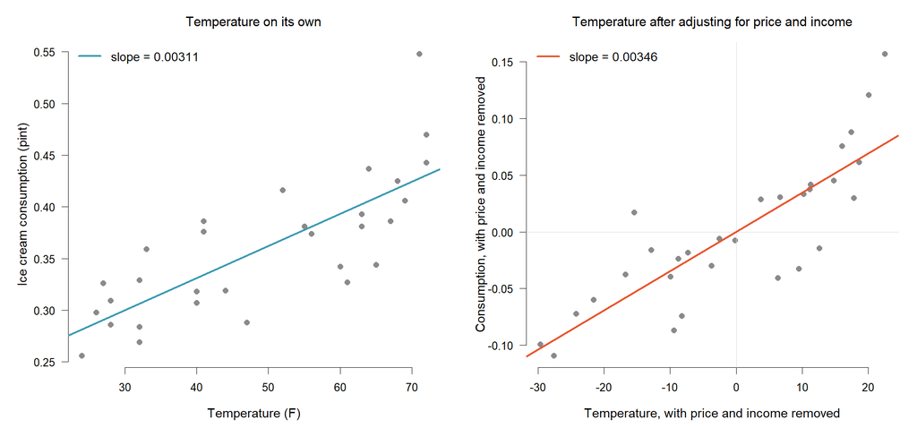

Temperature slope before and after adjusting for price and income, ice cream data (n = 30)

- 왼쪽 기울기 $0.003107$ = 온도만 넣은 **단순회귀**의 계수. 오른쪽 기울기 $0.003462$ = 가격·소득의 몫을 양쪽에서 걷어 낸 뒤의 기울기이며, 완전모형의 $\hat\beta_{\text{temp}}$ 와 일치(차이 $8.7\times10^{-19}$)
- 오른쪽 직선은 반드시 원점을 지남. 두 축이 모두 잔차라 평균이 0이기 때문

## 회귀계수의 해석: 유의하지 않은 계수

### 증거 부족과 효과 없음

**p-value가 큰 계수를 읽는 법**

- price: $\hat\beta_1=-1.03$, $p=0.226$
- 부호는 예상과 일치하나, 이 자료에서 효과를 뒷받침할 증거는 부족
- “증거 부족”은 “효과가 없다”는 증명이 아님
- 가격이 움직인 범위가 좁으면 효과가 있어도 잡아내기 어려움

가격을 식에서 뺄 것인지는 Diagnosis & Variable Selection 장의 변수선택에서 판단

## 모형의 설명력: 수정 $R^2$

### $R^2$ 의 단조 증가

설명변수를 추가하면 $R^2$ 는 결코 감소하지 않는다. 설명변수 개수가 다른 모형을 $R^2$ 만으로 비교할 수 없는 이유다.

### 정의

$$\bar R^2 = 1-\frac{SSE/(n-p-1)}{SST/(n-1)}$$

**기호**

- $SSE=\sum_{i=1}^n e_i^2$: 잔차제곱합($e_i=y_i-\hat y_i$), $n$: 관측 수, $p$: 설명변수 개수
- $SST=\sum_{i=1}^n(y_i-\bar y)^2$: 총제곱합($\bar y$ 는 $y$ 의 평균)
- $p$ 가 커지면 나누는 수 $n-p-1$ 이 작아져 벌점이 붙음. 쓸모없는 변수를 넣으면 $\bar R^2$ 는 오히려 내려감

## $R^2$, 수정 $R^2$, SSE의 관계

### 세 값의 이동 방향

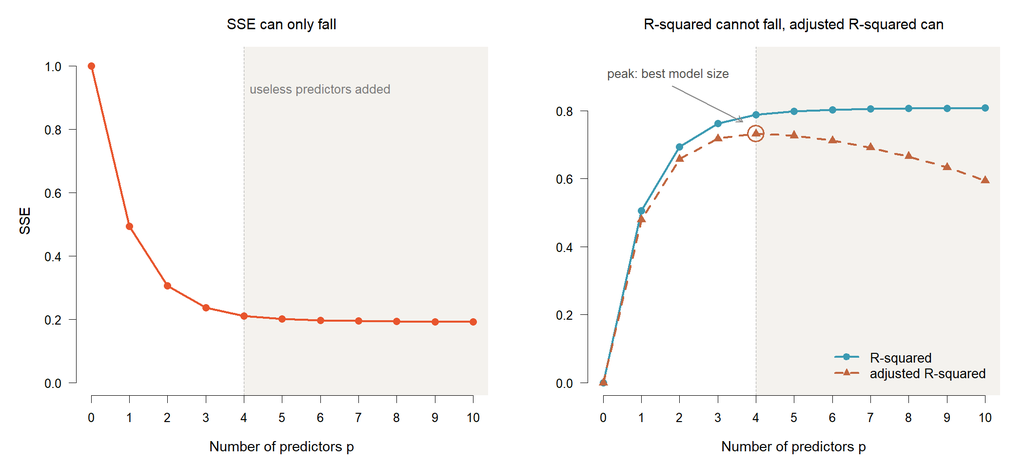

Schematic. Only the R-squared curve is stipulated; SSE and adjusted R-squared are derived from it by their definitions with n = 20

- $SST$ 가 고정이므로 $R^2=1-SSE/SST$ 는 SSE를 뒤집은 값일 뿐. 왼쪽이 내려가면 파란 선은 반드시 올라감. **$R^2$ 는 변수 추가에 반대할 수 없는 지표**
- 수정 $R^2$ 는 두 제곱합을 각자의 자유도로 나누므로, 새 변수가 자유도 하나 값을 못 벌면 **내려감**. 회색 구간이 그런 변수들이 들어간 자리이고, 꺾이는 지점이 적정 모형 크기

## 모형의 설명력: 세 모형 비교

### 벌점을 적용한 비교

$R^2$ and adjusted $R^2$ for three nested models (n = 30)

| Model | $R^2$ | Adjusted $R^2$ |
| --- | --- | --- |
| IC ~ temp | 0.602 | 0.587 |
| IC ~ income + temp | 0.702 | 0.680 |
| IC ~ price + income + temp | 0.719 | 0.686 |

**읽기**

- $R^2$ 는 변수를 넣을수록 0.602, 0.702, 0.719로 계속 오름. 상승 자체는 당연
- 수정 $R^2$ 는 0.587, 0.680, 0.686. 벌점을 적용해도 상승
- 모형끼리 비교할 때 보는 값은 수정 $R^2$. 두 변수 모형과 세 변수 모형의 차이는 0.006으로 작음

## 제곱합의 분해

### 총변동의 분해

$$\underbrace{\sum_{i=1}^{n}(y_i-\bar y)^2}_{\mathrm{SST}}
=\underbrace{\sum_{i=1}^{n}(\hat y_i-\bar y)^2}_{\mathrm{SSR}}
+\underbrace{\sum_{i=1}^{n}(y_i-\hat y_i)^2}_{\mathrm{SSE}}$$

**유도**

$y_i-\bar y$ 를 적합값이 설명한 조각과 잔차로 쪼갠 뒤 제곱하면 교차항이 하나 생김

$$\sum(y_i-\bar y)^2=\sum\big\{(\hat y_i-\bar y)+e_i\big\}^2
=\mathrm{SSR}+\mathrm{SSE}+2\sum(\hat y_i-\bar y)\,e_i$$

앞 장의 성질 $\mathbf X^\top\mathbf e=\mathbf 0$ 에서 $\sum e_i=0$ 이고 $\hat{\mathbf y}^\top\mathbf e=\hat{\boldsymbol\beta}^\top\mathbf X^\top\mathbf e=0$ 이므로

$$\sum(\hat y_i-\bar y)\,e_i=\underbrace{\sum \hat y_i e_i}_{=\,0}-\;\bar y\underbrace{\sum e_i}_{=\,0}=0$$

교차항이 사라져 제곱합이 그대로 둘로 나뉨. 두 조각이 **직교**하기 때문이며, 직각삼각형에서 빗변의 제곱이 두 변의 제곱의 합이 되는 것과 같은 구조

## 자유도의 분해

### 자유도의 동반 분해

제곱합만 나뉘는 것이 아니라 자유도도 정확히 나뉨: $p+(n-p-1)=n-1$

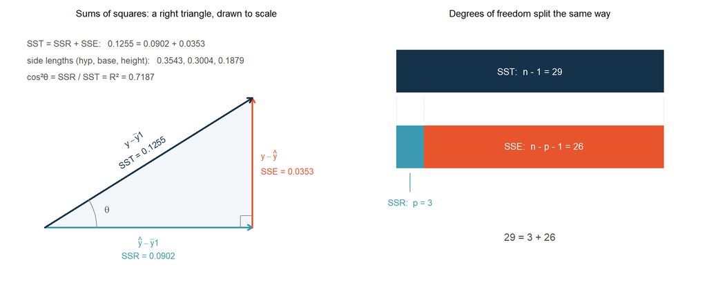

Sums of squares and degrees of freedom split the same way (ice cream model, n = 30, p = 3)

- 왼쪽 두 변이 **직각**인 것이 곧 $\sum(\hat y_i-\bar y)e_i=0$. 그래서 $\mathrm{SST}=\mathrm{SSR}+\mathrm{SSE}$ 는 피타고라스 정리 그 자체이며, 세 변의 길이는 각 제곱합의 제곱근
- 빗변과 밑변이 이루는 각 $\theta$ 에 대해 $\cos^2\theta=\mathrm{SSR}/\mathrm{SST}=R^2=0.719$. 각이 작을수록 설명력이 큼
- 총 자유도가 $n$ 이 아니라 $n-1$ 인 이유: $\bar y$ 를 구하는 데 정보 하나를 이미 씀. 잔차 자유도 $n-p-1$ 은 앞 장의 $\operatorname{tr}(\mathbf I-\mathbf H)$ 와 같은 값이고 $30-3-1=26$

## 모형 전체의 유의성: 검정의 목적

### 개별 계수에 앞선 검정

개별 계수를 하나씩 따지기 전에 먼저 물어야 할 것: 설명변수를 모두 합쳐도 반응변수를 설명하지 못하는 것은 아닌가?

### 가설

$H_0:\ \beta_1=\beta_2=\cdots=\beta_p=0$ (절편을 제외한 모든 회귀계수가 0)

$H_1:$ 적어도 하나의 $\beta_j$ 는 0이 아니다

**기호**

- $H_0$: 귀무가설(기각 대상이 되는 기본 주장)
- $H_1$: 대립가설

## 모형 전체의 유의성: F 통계량

### 설명한 몫과 남은 몫

$$F=\frac{SSR/p}{SSE/(n-p-1)}$$

**기호**

- $SSR=\sum_{i=1}^n(\hat y_i-\bar y)^2$: 회귀제곱합. 모형이 설명한 부분
- $SSE=\sum_{i=1}^n e_i^2$: 잔차제곱합. 설명하지 못한 부분
- 나누는 수 $p$ 와 $n-p-1$: **자유도**. 자료가 담은 정보 가운데 그 몫에 배정된 개수
- 관측 $n$ 개에서 계수 $p+1$ 개를 추정하는 데 쓰고 남은 것이 잔차의 자유도. 이 자료에서는 $30-3-1=26$
- $H_0$ 가 참이면 분자와 분모가 모두 $\sigma^2$ 의 불편추정량이 되어 $F$ 는 1 근처. 설명한 부분이 커질수록 $F$ 가 커져 $H_0$ 를 기각
- $H_0$ 아래에서 $F\sim F(p,\;n-p-1)$. 아이스크림 완전모형은 $F(3,26)$
- 점검 순서: 모형 전체(F-검정) 통과 $\to$ 개별 계수(t-검정)

**$R^2$ 로 다시 쓰면**: 분자와 분모를 $\mathrm{SST}$ 로 나누면 $F$ 가 결정계수만의 함수가 됨

$$F=\frac{R^2/p}{(1-R^2)/(n-p-1)}$$

$R^2$ 가 같아도 $p$ 가 크면 $F$ 는 작아짐. **설명력과 모형의 크기를 함께 보는 통계량**

## 회귀분산분석표

### 아이스크림 완전모형

Analysis of variance for the ice cream full model (n = 30, p = 3)

| Source | Df | Sum Sq | Mean Sq | $F$ | $p$-value |
| --- | --- | --- | --- | --- | --- |
| Regression | 3 | 0.0902 | 0.0301 | 22.1 | $2.5\times10^{-7}$ |
| Residual | 26 | 0.0353 | 0.00136 | n.a. | n.a. |
| Total | 29 | 0.126 | n.a. | n.a. | n.a. |

**표 읽는 법**

- **Mean Sq** = Sum Sq를 Df로 나눈 값, 곧 **자유도 하나당 변동**. 크기가 다른 두 제곱합을 비교할 수 있게 만드는 척도 조정
- $F=\mathrm{MSR}/\mathrm{MSE}=0.0301/0.00136=22.1$. $F(3,26)$ 의 5% 임계값 2.98을 크게 넘으므로 $H_0$ 기각
- $\mathrm{MSE}=0.00136$ 이 오차분산 $\sigma^2$ 의 추정값이고, 그 제곱근 $\hat\sigma=0.0369$ 가 완전모형의 잔차 표준오차
- 세로 방향으로 제곱합과 자유도가 각각 더해짐: $0.0902+0.0353=0.126$, $3+26=29$

**단순회귀에서는 t검정과 같은 결론**: 설명변수가 하나면 $F(1,n-2)=\{t(n-2)\}^2$ 이므로 두 검정이 완전히 일치. 온도만 넣은 단순회귀에서 $t=6.50$, 그 제곱 $6.50^2=42.3$ 이 그대로 $F$ 값

## 회귀계수 일부에 대한 검정

### 여러 변수의 동시 제거

완전모형(FM)에서 계수 $k$ 개를 0으로 놓은 축소모형(RM)을 세우고, 두 모형의 잔차제곱합 차이를 완전모형의 오차분산으로 잰다.

$$F=\frac{\{SSE(\text{RM})-SSE(\text{FM})\}/k}{SSE(\text{FM})/(n-p-1)}\ \sim\ F(k,\ n-p-1)\quad(H_0\text{ 아래에서})$$

**기호**

- $k$: 0으로 놓은 계수의 개수
- $SSE(\text{RM})\ge SSE(\text{FM})$ 은 항상 성립하므로 분자는 음수가 될 수 없음
- 분자는 **뺀 변수들이 실제로 설명한 몫**을 뜻함

Test of H0: price and income coefficients are both zero (ice cream data, n = 30)

| Quantity | Value |
| --- | --- |
| $SSE$ (RM: temp only) | 0.050009 |
| $SSE$ (FM: price + income + temp) | 0.035313 |
| 차이 $/\,k=2$ | 0.007348 |
| $\hat\sigma^2=SSE(\text{FM})/26$ | 0.0013582 |
| $F$ | 5.410 |
| $p$-value | 0.0109 |

## 회귀계수의 표집분포: 추정량은 확률변수

### 참값과 오차의 몫

한 번의 자료에서 계산한 $\hat{\boldsymbol\beta}$ 는 미지 계수 $\boldsymbol\beta$ 를 추정한 표본 결과이며, 자료가 바뀌면 값이 달라지는 **확률변수**이다. 자료를 다시 모아 같은 계산을 반복하면 추정값이 조금씩 달라지며, 그 값들이 이루는 분포가 **표집분포(sampling distribution)**

1. **정의에서 출발한다.** 관측한 $\mathbf y$ 만으로 계산하는 식이며, 이 단계에는 미지의 참값이 아직 등장하지 않음
   $$\hat{\boldsymbol\beta}=(\mathbf X^\top\mathbf X)^{-1}\mathbf X^\top\mathbf y$$
2. **$\mathbf y$ 를 모형으로 바꿔 쓴다.** 참 모형 $\mathbf y=\mathbf X\boldsymbol\beta+\boldsymbol\varepsilon$ 를 대입. 관측값 안에 **참값이 만든 부분**과 **오차**가 함께 들어 있음을 드러내는 단계
   $$\hat{\boldsymbol\beta}=(\mathbf X^\top\mathbf X)^{-1}\mathbf X^\top(\mathbf X\boldsymbol\beta+\boldsymbol\varepsilon)$$
3. **분배한 뒤 상쇄시킨다.** 두 항으로 가르면 앞 항에서 $(\mathbf X^\top\mathbf X)^{-1}$ 와 $\mathbf X^\top\mathbf X$ 가 만나 항등행렬이 되므로 $\boldsymbol\beta$ 만 남음
   $$\hat{\boldsymbol\beta}=\underbrace{(\mathbf X^\top\mathbf X)^{-1}\mathbf X^\top\mathbf X}_{=\;\mathbf I}\boldsymbol\beta
   +(\mathbf X^\top\mathbf X)^{-1}\mathbf X^\top\boldsymbol\varepsilon$$

$$\hat{\boldsymbol\beta}=\underbrace{\boldsymbol\beta}_{\textstyle \text{고정된 참값}}
+\underbrace{(\mathbf X^\top\mathbf X)^{-1}\mathbf X^\top\boldsymbol\varepsilon}_{\textstyle \text{자료마다 달라지는 몫}}$$

## 회귀계수의 표집분포: 불편성

### 참값과의 일치

**전제 조건**

- $\mathbf X$ 를 고정된 것으로 두고 조건부로 생각
- $E(\boldsymbol\varepsilon\mid\mathbf X)=\mathbf 0$: 오차의 평균이 0
- $\operatorname{Var}(\boldsymbol\varepsilon\mid\mathbf X)=\sigma^2\mathbf I$: 오차의 분산이 모두 $\sigma^2$ 로 같고 서로 무관

$E(\hat{\boldsymbol\beta}\mid\mathbf X)=\boldsymbol\beta$: 최소제곱 추정량의 기댓값은 참값과 일치한다(불편추정량).

Population coefficient versus its estimator

| Symbol | Nature | Meaning |
| --- | --- | --- |
| $\boldsymbol\beta$ | Fixed unknown constant | 모집단의 참 회귀계수 |
| $\hat{\boldsymbol\beta}$ | Random variable | 표본이 바뀌면 달라지는 추정량 |

## 회귀계수의 분산: 분산-공분산 행렬

### 오차분산과 설계행렬

앞의 전제 조건 아래에서 최소제곱 추정량의 분산-공분산 행렬은 오차분산과 설계행렬만으로 결정된다.

$$\operatorname{Var}(\hat{\boldsymbol\beta}\mid\mathbf X)=\sigma^2(\mathbf X^\top\mathbf X)^{-1}$$

**기호**

- $\sigma^2$: 오차분산
- $(\mathbf X^\top\mathbf X)^{-1}$: 설계정보 행렬의 역행렬
- 대각 원소가 각 계수의 분산 $\operatorname{Var}(\hat\beta_j\mid\mathbf X)$, 비대각 원소가 계수 사이의 공분산

## 회귀계수의 분산: 불확도의 결정 요인

### 잡음의 크기와 설계의 정보량

**오차의 크기**

- 잡음이 클수록 $\sigma^2$ 가 커지고 계수의 불확도가 **증가**
- 같은 설계에서 잡음이 두 배면 분산도 두 배

**설계의 정보량**

- 설명변수의 변동이 크고 서로 겹치지 않을수록 $(\mathbf X^\top\mathbf X)^{-1}$ 가 작아져 불확도가 **감소**
- 설명변수끼리 정보가 겹치면 역행렬이 커지고 표준오차도 커짐

**실제 계산**

- 오차분산은 알 수 없으므로 잔차로 추정: $\hat\sigma^2=SSE/(n-p-1)$
- $j$번째 계수의 표준오차: $\operatorname{se}(\hat\beta_j)=\sqrt{\widehat{\operatorname{Var}}(\hat\beta_j)}$
- $SSE$는 잔차제곱합, $n$은 관측 수, $p$는 설명변수 개수, $n-p-1$은 잔차의 자유도

## 분산식의 유도: 세 단계

### 전달 $\to$ 선형변환 $\to$ 상쇄

1. **추정량을 오차의 함수로 바꾼다.** $\hat{\boldsymbol\beta}$ 의 정의에 모형 $\mathbf y=\mathbf X\boldsymbol\beta+\boldsymbol\varepsilon$ 를 대입하면 앞의 두 항이 상쇄되어 $\boldsymbol\beta$ 만 남음. 흔들리는 부분은 오차가 통로 $\mathbf A$ 를 지나온 것뿐
   $$\hat{\boldsymbol\beta}=(\mathbf X^\top\mathbf X)^{-1}\mathbf X^\top(\mathbf X\boldsymbol\beta+\boldsymbol\varepsilon)
   =\boldsymbol\beta+\underbrace{(\mathbf X^\top\mathbf X)^{-1}\mathbf X^\top}_{\textstyle \mathbf A}\boldsymbol\varepsilon$$
   $E(\boldsymbol\varepsilon)=\mathbf 0$ 이므로 이 한 줄이 **불편성** $E(\hat{\boldsymbol\beta})=\boldsymbol\beta$ 도 함께 증명
2. **선형변환의 분산 성질을 쓴다.** 상수행렬 $\mathbf A$ 와 확률벡터 $\mathbf z$ 에 대해 $\operatorname{Var}(\mathbf A\mathbf z)=\mathbf A\operatorname{Var}(\mathbf z)\mathbf A^\top$. $\mathbf X$ 를 고정으로 보므로 $\mathbf A$ 가 상수행렬이 됨
   $$\operatorname{Var}(\hat{\boldsymbol\beta}\mid\mathbf X)=\operatorname{Var}(\mathbf A\boldsymbol\varepsilon)=\mathbf A\operatorname{Var}(\boldsymbol\varepsilon)\mathbf A^\top$$
3. **대입하면 저절로 상쇄된다.** $\operatorname{Var}(\boldsymbol\varepsilon)=\sigma^2\mathbf I$ 를 넣고, $(\mathbf X^\top\mathbf X)^{-1}$ 가 대칭이라 $\mathbf A^\top=\mathbf X(\mathbf X^\top\mathbf X)^{-1}$ 임을 쓰면 가운데에 $\mathbf X^\top\mathbf X$ 가 생겨 역행렬 하나와 사라짐
   $$\mathbf A(\sigma^2\mathbf I)\mathbf A^\top
   =\sigma^2(\mathbf X^\top\mathbf X)^{-1}\underbrace{\mathbf X^\top\mathbf X}_{\textstyle \text{상쇄}}(\mathbf X^\top\mathbf X)^{-1}$$

$$\operatorname{Var}(\hat{\boldsymbol\beta}\mid\mathbf X)=\sigma^2(\mathbf X^\top\mathbf X)^{-1}$$

## 분산식의 유도: 결과 읽기

### 단계별로 쓰인 가정

Where each assumption enters the variance derivation

| Step | 사용한 가정 | 깨지면 생기는 일 |
| --- | --- | --- |
| 1. 오차의 함수로 | 모형이 옳음 ($E(\boldsymbol\varepsilon)=\mathbf 0$) | 추정량이 **편향**됨. 분산 이전의 문제 |
| 2. 선형변환 | $\mathbf X$ 는 고정 (확률변수 아님) | 조건부가 아닌 분산은 더 복잡해짐 |
| 3. $\operatorname{Var}(\boldsymbol\varepsilon)=\sigma^2\mathbf I$ | **등분산**(대각원소가 모두 같음) + **독립**(대각 밖이 0) | 계수 추정값은 그대로여도 **표준오차가 틀림** |

- 결과가 $\sigma^2\times(\mathbf X^\top\mathbf X)^{-1}$ 로 **깔끔히 분리**됨. 앞은 측정의 잡음, 뒤는 설계가 담은 정보. 실험을 설계할 때 손댈 수 있는 쪽은 뒤쪽
- $j$번째 계수의 표준오차 $\operatorname{se}(\hat\beta_j)=\hat\sigma\sqrt{c_{jj}}$, 계수 사이 공분산은 비대각원소 $\sigma^2c_{jk}$. 결과표의 표준오차와 신뢰구간이 모두 이 한 식에서 나옴

## Gauss-Markov 정리: 가정

### 정리가 성립할 조건

**정리가 성립하기 위한 조건**

- **선형모형**: $\mathbf y=\mathbf X\boldsymbol\beta+\boldsymbol\varepsilon$
- **오차 평균 0**: $E(\boldsymbol\varepsilon\mid\mathbf X)=\mathbf 0$
- **등분산**: 모든 $i$ 에 대해 $\operatorname{Var}(\varepsilon_i\mid\mathbf X)=\sigma^2$
- **무상관**: $i\neq j$ 에 대해 $\operatorname{Cov}(\varepsilon_i,\varepsilon_j\mid\mathbf X)=0$
- **full rank**: $\mathbf X$ 의 열들이 선형독립, 즉 $(\mathbf X^\top\mathbf X)^{-1}$ 가 존재

등분산과 무상관을 함께 쓰면 $\operatorname{Var}(\boldsymbol\varepsilon\mid\mathbf X)=\sigma^2\mathbf I$. **정규성은 이 목록에 없음**

## Gauss-Markov 정리: BLUE

### 최소분산 선형 불편추정량

**Theorem (Gauss-Markov)**

앞의 가정이 성립하면, 최소제곱 추정량 $\hat{\boldsymbol\beta}=(\mathbf X^\top\mathbf X)^{-1}\mathbf X^\top\mathbf y$ 는 $\mathbf y$ 의 선형함수이면서 불편인 모든 추정량 가운데 분산이 가장 작다.

**BLUE 네 글자의 뜻**

- **B**est: 같은 부류의 추정량 중 분산이 가장 작음
- **L**inear: 관측값 $\mathbf y$ 의 선형함수
- **U**nbiased: $E(\hat{\boldsymbol\beta})=\boldsymbol\beta$
- **E**stimator: 추정량

## Gauss-Markov 정리: 결론별 필요 가정

### 정규성의 역할

Assumptions required for each inferential conclusion (Kutner et al., 2005; Faraway, 2015)

| Conclusion | Required assumptions |
| --- | --- |
| $\hat{\boldsymbol\beta}$ is BLUE | 평균 0, 등분산, 무상관, full rank |
| Exact $t$, $F$ tests and interval estimation | 위 조건에 오차의 **정규성**을 추가 |

- 정규분포는 평균을 중심으로 좌우대칭인 종 모양 분포. 오차가 이 분포를 따른다는 가정이 정규성
- 정규성은 BLUE 자체에 필수가 아니며, 정확한 $t$, $F$ 검정과 구간 추론에 추가로 쓰임
- **등분산이 깨지면 최소제곱은 더 이상 BLUE가 아님**: Weighted Regression 장으로 이어지는 지점

## 표준오차에서 신뢰구간으로

### 자유도 $n-p-1$ 의 $t$ 분포

정규오차 가정 아래에서 표준화된 계수 추정량은 자유도 $n-p-1$ 인 $t$ 분포를 따른다.

$$\frac{\hat\beta_j-\beta_j}{\operatorname{se}(\hat\beta_j)}\sim t_{\,n-p-1}
\qquad\Longrightarrow\qquad
\hat\beta_j\pm t_{\alpha/2,\,n-p-1}\operatorname{se}(\hat\beta_j)$$

- $t$ 분포는 정규분포처럼 좌우대칭인 종 모양이나 꼬리가 더 두꺼움. 자유도가 커질수록 정규분포에 근접
- $\operatorname{se}(\hat\beta_j)$: 표준오차, $t_{\alpha/2,\,n-p-1}$: 자유도 $n-p-1$ 인 $t$ 분포의 임계값
- 오른쪽 식이 $100(1-\alpha)\%$ 신뢰구간

## 회귀계수에 대한 검정과 신뢰구간

### $(\mathbf X^\top\mathbf X)^{-1}$ 의 대각원소

$$\operatorname{se}(\hat\beta_j)=\hat\sigma\sqrt{c_{jj}},\qquad
t=\frac{\hat\beta_j}{\operatorname{se}(\hat\beta_j)}\sim t_{\,n-p-1},\qquad
\hat\beta_j\pm t_{\alpha/2,\,n-p-1}\,\hat\sigma\sqrt{c_{jj}}$$

**기호**

- $c_{jj}$: $(\mathbf X^\top\mathbf X)^{-1}$ 의 $j$번째 대각원소
- $\hat\sigma^2=SSE/(n-p-1)=0.0013582$, $t_{0.025,\,26}=2.0555$

Coefficient tests and 95% confidence intervals for the ice cream full model (n = 30, p = 3)

| Term | $\hat\beta_j$ | $c_{jj}$ | $\operatorname{se}$ | $t$ | $p$-value | 95% CI |
| --- | --- | --- | --- | --- | --- | --- |
| (Intercept) | 0.19270 | 53.3248 | 0.26912 | 0.72 | 0.480 | $(-0.360,\ 0.746)$ |
| price | −1.02906 | 507.6785 | 0.83037 | −1.24 | 0.226 | $(-2.736,\ 0.678)$ |
| income | 0.00331 | 0.001011 | 0.00117 | 2.83 | 0.0089 | $(0.00090,\ 0.00572)$ |
| temp | 0.00346 | 0.000146 | 0.00045 | 7.77 | < 0.001 | $(0.00255,\ 0.00438)$ |

**보고 항목**: 추정값, 표준오차, 95% 신뢰구간, 분석에 쓴 가정과 표본 범위. 구간이 0을 포함하면 그 계수는 유의하지 않음(price가 그 경우). 95%가 붙는 대상은 계수가 아니라 **구간을 만드는 절차**이며, 자세한 해석은 2장 **신뢰구간** 참조

## 반응평균의 신뢰구간과 예측구간: 정의

### 평균과 개별 관측

새 설명변수 조합 $\mathbf x_0=(1,\ x_{01},\dots,x_{0p})^\top$ 에서 적합값은 $\hat y_0=\mathbf x_0^\top\hat{\boldsymbol\beta}$ 로 같으나, 목표가 **조건부 평균**인지 **새 관측 하나**인지에 따라 구간의 폭이 달라진다.

$$\text{신뢰구간}:\ \hat y_0\pm t_{\alpha/2,\,n-p-1}\,\hat\sigma\sqrt{\mathbf x_0^\top(\mathbf X^\top\mathbf X)^{-1}\mathbf x_0}$$

$$\text{예측구간}:\ \hat y_0\pm t_{\alpha/2,\,n-p-1}\,\hat\sigma\sqrt{1+\mathbf x_0^\top(\mathbf X^\top\mathbf X)^{-1}\mathbf x_0}$$

- 근호 안의 $1$ 이 두 구간을 가르는 전부. 새 관측에는 개별 오차 $\varepsilon_0$ 이 추가로 실리기 때문. 따라서 **예측구간이 항상 더 넓음**
- $\mathbf x_0^\top(\mathbf X^\top\mathbf X)^{-1}\mathbf x_0$ 는 $\mathbf x_0$ 가 자료의 중심에서 멀수록 커짐. 자료 범위 밖으로 외삽하면 두 구간 모두 급격히 넓어짐

## 반응평균의 신뢰구간과 예측구간: 수치

### 아이스크림 자료, 새 조건

$\mathbf x_0=(1,\ 0.280,\ 85,\ 65)^\top$ 에서 $\hat y_0=0.19270-1.02906\times0.280+0.00331\times85+0.00346\times65=0.41107$

$$\mathbf x_0^\top(\mathbf X^\top\mathbf X)^{-1}\mathbf x_0=0.089095,\qquad
\hat\sigma=0.036853,\qquad t_{0.025,\,26}=2.0555$$

Two intervals at price = 0.280, income = 85, temp = 65 (ice cream full model, n = 30)

| Interval | Half-width | Result | Width |
| --- | --- | --- | --- |
| 신뢰구간 (평균반응) | $t\hat\sigma\sqrt{0.089095}=0.02261$ | $(0.38846,\ 0.43368)$ | 0.0452 |
| 예측구간 (새 관측) | $t\hat\sigma\sqrt{1.089095}=0.07906$ | $(0.33201,\ 0.49013)$ | 0.1581 |

예측구간의 폭이 신뢰구간의 **3.50배**. 근호 안의 $1$ 이 $0.0891$ 을 압도하기 때문이며, 검교정에서 **다음 측정값 하나를 보증**해야 한다면 반드시 예측구간을 씀

## 이 장의 정리

### 정리

- 원인이 여럿이면 조건도 여럿으로: $E(Y\mid x_1,\dots,x_p)=\beta_0+\beta_1x_1+\cdots+\beta_px_p$
- 최소제곱 해는 변수 개수와 무관하게 정규방정식 $\mathbf X^\top\mathbf X\boldsymbol\beta=\mathbf X^\top\mathbf y$ 에서 $\hat{\boldsymbol\beta}=(\mathbf X^\top\mathbf X)^{-1}\mathbf X^\top\mathbf y$ 하나로 정리됨
- 모자행렬 $\mathbf H=\mathbf X(\mathbf X^\top\mathbf X)^{-1}\mathbf X^\top$ 는 $\mathbf y$ 를 설계행렬의 열공간에 수직으로 내리는 사영
- 계수는 “다른 변수를 고정했을 때”라는 조건절과 함께 읽을 것
- 계수의 흔들림은 $\operatorname{Var}(\hat{\boldsymbol\beta}\mid\mathbf X)=\sigma^2(\mathbf X^\top\mathbf X)^{-1}$ 이 결정. 등분산이 깨지지 않는 한 최소제곱은 BLUE

**다음 장**: Diagnosis & Variable Selection: 이렇게 세운 모형을 그대로 믿어도 되는가. 잔차로 가정을 점검하고 변수를 고른다

## 참고문헌

### 이 장에서 인용한 문헌

- Hoaglin, D. C., & Welsch, R. E. (1978). The hat matrix in regression and ANOVA. *The American Statistician*, 32(1), 17-22.
- Kutner, M. H., et al. (2005). *Applied Linear Statistical Models*, 5th ed. McGraw-Hill. (계수 해석, 추론에 필요한 가정)
- Faraway, J. J. (2015). *Linear Models with R*, 2nd ed. CRC Press. (결론별 필요 가정)

### 교과서

- Kutner, M. H., Nachtsheim, C. J., Neter, J., & Li, W. (2005). *Applied Linear Statistical Models*, 5th ed. McGraw-Hill.
- Faraway, J. J. (2015). *Linear Models with R*, 2nd ed. CRC Press.